# Capital Bikeshare - Improving Ridership With Data Science

DS241 final project Fall 2023

Joshua Allessio, Kashyap Vallur and Marco Camalich

## Problem Statement

Washington DC’s public bikeshare dataset is a classic data science project. Much can be gleaned from this data. In this report, we set out to determine if any of the bike stations were particularly efficient or inefficient in 2023. We will analyze how much each station is used, and draw conclusions about how to optimally position the bicycle infrastructure in order to maximize ridership.

## Document Setup

Below, we will install R packages required for analysis.

```r
required_packages <- c("tidyverse", "janitor", "here", "openmeteo", "lubridate", "forcats", "dplyr")

for (packages in required_packages) {
  if (!require(packages, character.only = TRUE)) {
    install.packages(packages, dependencies = TRUE)
    library(packages, character.only = TRUE)
  }
}
```

```
here() starts at C:/Users/la_pa/OneDrive/Documentos/R/bikeshare_23
```

```r
if (all(sapply(required_packages, requireNamespace, quietly = TRUE))) {
  cat("All required packages are loaded.\n")
} else {
  warning("Some packages failed to load.")
}
```

```
All required packages are loaded.
```

## Create a function to filter useless data from the data set

```r
filter_bikeshare <- function(df) {
  df |> filter(
    !is.na(start_station_name) & !is.na(start_station_id) & start_station_name != "" & start_station_id != "" &
    !is.na(end_station_name) & !is.na(end_station_id) & end_station_name != "" & end_station_id != "" &
    !is.na(start_lat) & !is.na(start_lng) & !is.na(end_lng)
  )
  df <- df |>
    mutate(duration = as.numeric(difftime(ended_at, started_at))) |>
    filter(duration > 30) |>  # Longer than 30 seconds
    filter (duration < 46800) # Less than 13 hours
return(df)
}
```

```r
df_01=read_csv(here("data_raw", "202301-capitalbikeshare-tripdata.csv"))
```

```r
df_02=read_csv(here("data_raw", "202302-capitalbikeshare-tripdata.csv"))
```

```r
df_03=read_csv(here("data_raw", "202303-capitalbikeshare-tripdata.csv"))
```

```r
df_04=read_csv(here("data_raw", "202304-capitalbikeshare-tripdata.csv"))
```

```r
df_05=read_csv(here("data_raw", "202305-capitalbikeshare-tripdata.csv"))
```

```r
df_06=read_csv(here("data_raw", "202306-capitalbikeshare-tripdata.csv"))
```

```r
df_07=read_csv(here("data_raw", "202307-capitalbikeshare-tripdata.csv"))
```

```r
df_08=read_csv(here("data_raw", "202308-capitalbikeshare-tripdata.csv"))
```

```r
df_09=read_csv(here("data_raw", "202309-capitalbikeshare-tripdata.csv"))
```

```r
df_10=read_csv(here("data_raw", "202310-capitalbikeshare-tripdata.csv"))
```

## Tidy the Data

```r
df_01 <- filter_bikeshare(df_01)
df_02 <- filter_bikeshare(df_02)
df_03 <- filter_bikeshare(df_03)
df_04 <- filter_bikeshare(df_04)
df_05 <- filter_bikeshare(df_05)
df_06 <- filter_bikeshare(df_06)
df_07 <- filter_bikeshare(df_07)
df_08 <- filter_bikeshare(df_08)
df_09 <- filter_bikeshare(df_09)
df_10 <- filter_bikeshare(df_10)
```

Here, we use the custom function from earlier to tidy the 10 data sets.

## Aggregate the Data

Aggregate the data into one data frame and begin with a simple visualization

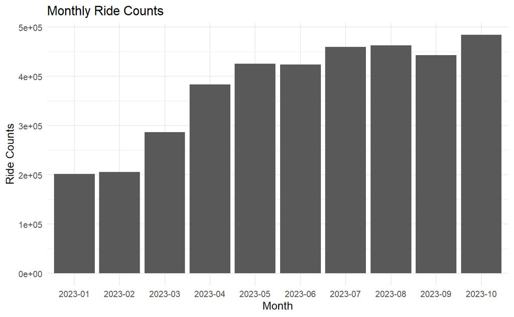

```r
all_data <- bind_rows(
  df_01, df_02, df_03, df_04, df_05, df_06, df_07, df_08, df_09, df_10,
  .id = "month"
)

all_data$started_at <- as.POSIXct(all_data$started_at, format = "%Y-%m-%d %H:%M:%S")
all_data$month <- format(all_data$started_at, "%Y-%m")

ggplot(all_data, aes(x = month)) +
  geom_bar() +
  labs(title = "Monthly Ride Counts",
       x = "Month",
       y = "Ride Counts") +
  theme_minimal()
```

This simple graph shows the trend in bike ridership throughout the year, and it also verifies that we have not made a mistake in tidying and aggregating our data.

## Begin with a Visualization

Right away, we can begin creating visualizations to get a better understanding of the users of the bikeshare program.

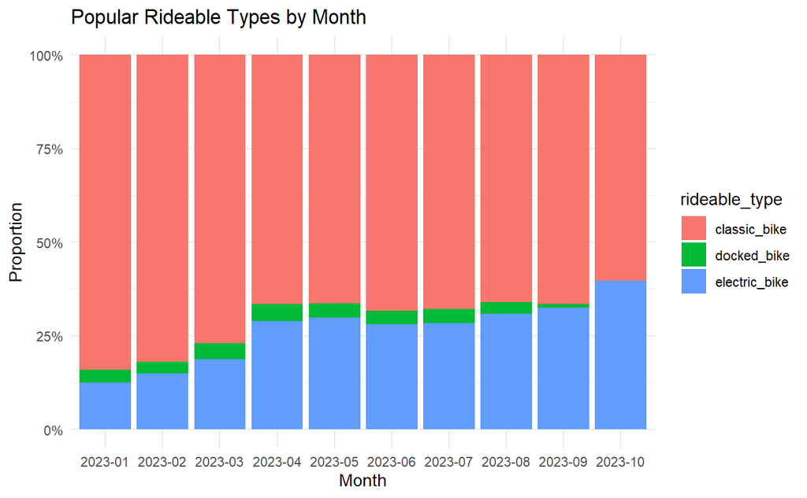

```r
ggplot(all_data, aes(x = month, fill = rideable_type)) +
  geom_bar(position = "fill") +
  labs(title = "Popular Rideable Types by Month",
       x = "Month",
       y = "Proportion") +
  theme_minimal() +
  scale_y_continuous(labels = scales::percent_format(scale = 100))
```

The above graph shows us that in general, riders are using the classic bikes, with a slight trend towards favoring the electric bikes later in the year.

## Find out how many bike stations there are

```r
unique_station_count <- all_data %>%
  filter(!is.na(start_station_name) & !is.na(start_station_id) & start_station_name != "" & start_station_id != "") %>%
  summarise(unique_stations = n_distinct(start_station_name))

cat("The total amount of unique stations is:", unique_station_count$unique_stations, "\n")
```

```
The total amount of unique stations is: 769
```

## Measure Activity At Each Station

In this code chunk, we count how many times each station name appears in the data set. The more a station’s name appears, the more it is used. We will be able to see which stations are the most useful, and which stations not being used in any significant capacity.

```r
# Combine start and end stations into one column and get the top 5 stations
all_stations <- bind_rows(
  select(all_data, station = start_station_name),
  select(all_data, station = end_station_name)
)

top_stations <- all_stations %>%
  filter(!is.na(station)) %>%
  count(station, sort = TRUE) %>%
  head(5)

print(top_stations)
```

| station | n |
| --- | --- |
| Columbus Circle / Union Station | 78283 |
| New Hampshire Ave & T St NW | 68926 |
| 15th & P St NW | 63360 |
| Lincoln Memorial | 59338 |
| 5th & K St NW | 58465 |

## Visualization - Station Use Throughout The Year

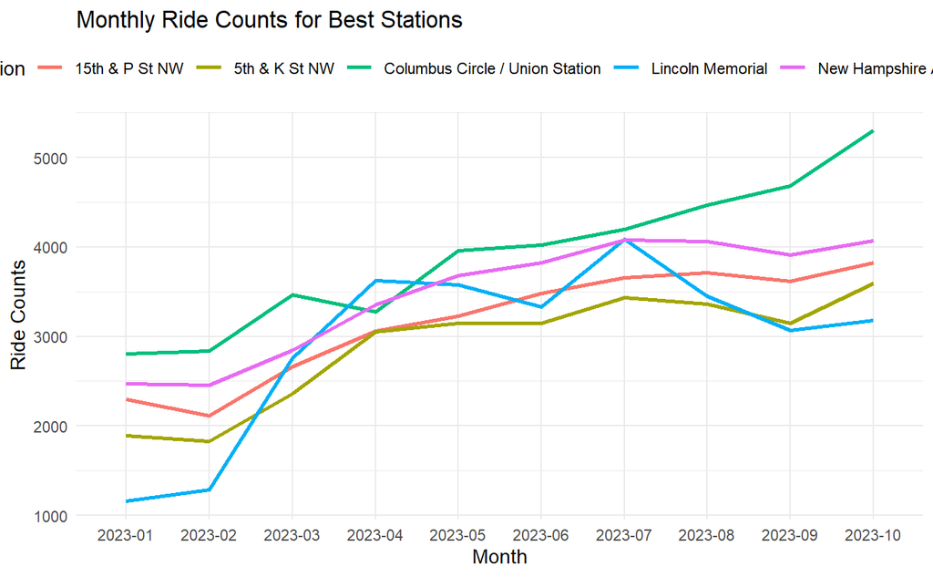

```r
# Convert month to a factor with the correct order
all_data$month <- factor(all_data$month, levels = unique(all_data$month))
top_stations_data <- all_data %>%
  filter(start_station_name %in% top_stations$station)

ggplot(top_stations_data, aes(x = month, color = start_station_name, group = start_station_name)) +
  geom_line(stat = "count", size = 1) +  # Adjust the size value as needed
  scale_x_discrete(name = "Month") +
  scale_y_continuous(name = "Ride Counts") +
  labs(title = "Monthly Ride Counts for Best Stations",
       color = "Station") +
  theme_minimal() +
  theme(legend.position = "top")
```

## Continue Observing Bike Station Activity

Now, we will see which stations were used the least.

```r
# Get the least active stations
worst_stations <- all_stations %>%
  filter(!is.na(station)) %>%
  count(station, sort = TRUE) %>%
  filter(n < 50) %>%
print(worst_stations)
```

| station | n |
| --- | --- |
| Beech Dr at Draper Dr Park | 14 |
| Fairfax Blvd & Pickett Rd South | 10 |
| Westbranch Dr & Jones Branch Dr | 9 |
| S Wayne and 9th St | 8 |
| Fairfax Blvd & Pickett Rd North | 7 |
| Reston Regional Library | 7 |
| 21st NW & E St NW | 3 |
| Layton Hall Dr & University Dr | 2 |
| Shady Grove Hospital | 2 |

```r
# Get 5 stations with little activity
bad_stations <- all_stations %>%
  filter(!is.na(station)) %>%       # exclude NA values
  count(station, sort = TRUE) %>%   # count how many times each station was used
  filter(n >= 50) %>%               # exclude
  tail(5)
print(bad_stations)
```

| station | n |
| --- | --- |
| Ridge Rd Community Center | 88 |
| 19th & Savannah St SE | 81 |
| Briggs Chaney Park & Ride | 77 |
| Inlet Ct & Wiehle Dr | 59 |
| Tysons One Pl & Chain Bridge Rd | 53 |

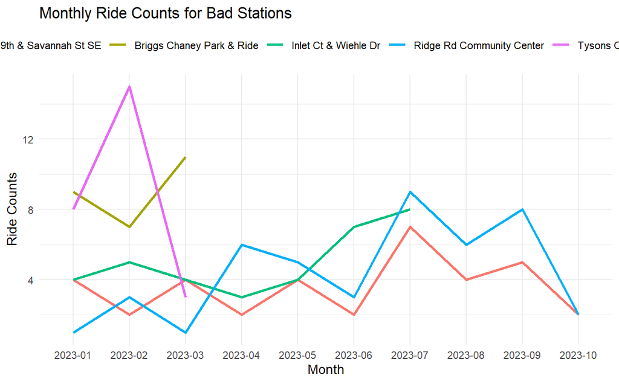

```r
# Convert month to a factor with the correct order
all_data$month <- factor(all_data$month, levels = unique(all_data$month))
bad_stations_data <- all_data %>%
  filter(start_station_name %in% bad_stations$station)

ggplot(bad_stations_data, aes(x = month, color = start_station_name, group = start_station_name)) +
  geom_line(stat = "count", size = 1) +  # Adjust the size value as needed
  scale_x_discrete(name = "Month") +
  scale_y_continuous(name = "Ride Counts") +
  labs(title = "Monthly Ride Counts for Bad Stations",
       color = "Station") +
  theme_minimal() +
  theme(legend.position = "top")
```

In the visualization above, we can see that the participation of the stations is considerably lower in contrast to the top stations. This leads us to observe there is a need to analyze why certain zones are getting people away from bike riding, as well as detecting the principal causes of station closures throughout the year.

## Conclusion

As you can see, the least used station is located at Shady Grove Hospital, with only 2 uses this year. That’s a big difference between the most used station, at 78,000 uses this year! Upon further research, we can discover that Shady Grove Hospital has been permanently closed. This news, in combination with the fact that the bike station was used only twice, makes a good case for the removal of this particular station. It should be removed, or relocated somewhere where it will be more useful.

However, for the bike station located at Westbranch Dr & Jones Branch Dr, and several others, there is no additional information to be found. It may be a good idea for the Capital Bikeshare organizers to look further into these little-used stations and relocate them to somewhere where they will be used.

By keeping track of bike station usage, we can be proactive in relocating bike stations to places where the resource will be more appropriate and potentially increase ridership by concentrating the bike stations to areas where they will be used.